# Create your Kotlin Multiplatform library – tutorial

In this tutorial, you'll learn how to create a multiplatform library in IntelliJ IDEA, publish the library to a local Maven repository, and add it as a dependency in another project.

The tutorial is based on our [multiplatform library template](https://github.com/Kotlin/multiplatform-library-template), which is a simple library containing a function to generate the Fibonacci sequence.

## Set up the environment

Install all the necessary tools and update them to the latest versions.

## Create a project

1. In IntelliJ IDEA, select File | New | Project from Version Control.
2. Enter the URL of the [multiplatform library template project](https://github.com/Kotlin/multiplatform-library-template):

   ```
   https://github.com/Kotlin/multiplatform-library-template
   ```

3. Click Clone.

## Examine the project structure

The Kotlin Multiplatform library template project provides a foundational structure for developing Kotlin Multiplatform libraries. This template helps create libraries that can operate across various platforms.

In the template project, `library` serves as the core module and contains the main source code and build resources for the multiplatform library.

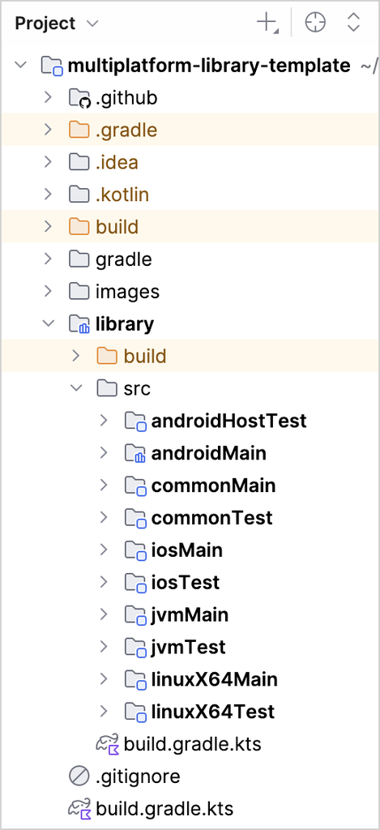

Let's focus on the `library` code that is shared across all platforms. Inside the `src/commonMain/kotlin` directory, you can find the `CustomFibi.kt` file with Kotlin Multiplatform code that defines a Fibonacci sequence generator:

```
package io.github.kotlin.fibonacci

// Defines the function to generate the Fibonacci sequence
fun generateFibi() = sequence {
    var a = firstElement
    yield(a)

    var b = secondElement
    yield(b)

    while (true) {
        val c = a + b
        yield(c)
        a = b
        b = c
    }
}

// Declares the expected values for `firstElement` and `secondElement`
expect val firstElement: Int
expect val secondElement: Int
```

The `firstElement` and `secondElement` properties are placeholders that the platform-specific code can implement. Each target should provide actual values by using the `actual` keyword in their respective source sets.

The `expect` declarations are matched with `actual` implementations. This mechanism is useful when writing cross-platform code that requires platform-specific behavior.

In this case, the multiplatform library template includes platform-specific implementations of the `firstElement` and `secondElement` properties. The `androidMain`, `iosMain`, `jvmMain`, and `linuxX64Main` directories contain `actual` declarations that provide values for these properties.

For example, here's the Android implementation included in `androidMain/kotlin/fibiprops.android.kt`:

```
package io.github.kotlin.fibonacci

actual val firstElement: Int = 1
actual val secondElement: Int = 2
```

The other platforms follow the same pattern, with variations in the values of `firstElement` and `secondElement` properties.

## Add a new platform

Now that you're familiar with how shared and platform-specific code works in the template, let's extend the project by adding support for an additional platform.

Configure support for the Kotlin/Wasm platform by using the expect / actual mechanism, then implement platform-specific functionality for the `firstElement` and `secondElement` properties.

### Add the Kotlin/Wasm target to your project

1. In the `library/build.gradle.kts` file, add the Kotlin/Wasm target (`wasmJs`) and source sets:

   ```
   kotlin {
       // ...
       @OptIn(org.jetbrains.kotlin.gradle.ExperimentalWasmDsl::class)
       wasmJs {
           browser()
           binaries.executable()
       }
       // ...
       sourceSets {
           //...
           wasmJsMain.dependencies {
               // Wasm-specific dependencies
           }
       }
   }
   ```

2. Synchronize the Gradle files by clicking the Sync Gradle Changes icon () that appears in your build file. Alternatively, click the refresh button in the Gradle tool window.

### Create platform-specific code for Wasm

After adding the Wasm target, you need a Wasm directory to hold the platform-specific implementation of `firstElement` and `secondElement`:

1. Right-click the `library/src` directory and select New | Directory.
2. Select wasmJsMain/kotlin from the Gradle Source Sets lists.

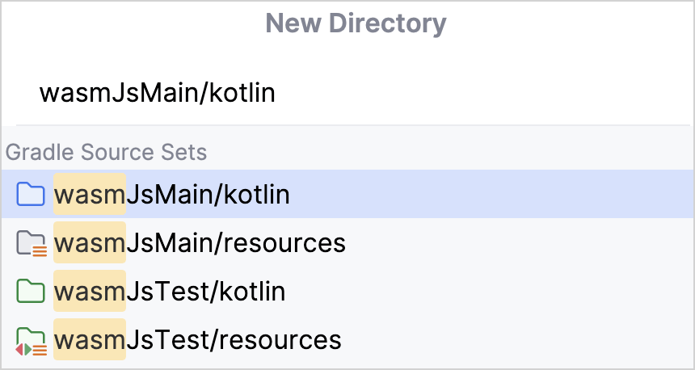

3. Right-click the newly created `wasmJsMain/kotlin` directory and select New | Kotlin Class/File.
4. Enter fibiprops.wasm as the name of the file and select File.
5. Add the following code to the `fibiprops.wasm.kt` file:

   This code sets a Wasm-specific implementation, defining `actual` values for `firstElement` as `3` and `secondElement` as `5`.

### Build the project

Make sure your project compiles correctly with the new platform:

1. Open the Gradle tool window by selecting View | Tool Windows | Gradle.
2. In multiplatform-library-template | library | Tasks | build, run the build task.

[figure not shown]

   Alternatively, run the following command in the terminal from the `multiplatform-library-template` root directory:

   ```
   ./gradlew build
   ```

You can see the successful output in the Build tool window.

## Publish your library to the local Maven repository

Your multiplatform library is ready for publishing locally so that you can use it in other projects on the same machine.

To publish your library, use the [`maven-publish`](https://docs.gradle.org/current/userguide/publishing_maven.html) Gradle plugin as follows:

1. In the `library/build.gradle.kts` file, locate the `plugins { }` block and apply the `maven-publish` plugin:

   ```
      plugins {
          // ...
          // Add the following line:
          id("maven-publish")
      }
   ```

2. Locate the `mavenPublishing {}` block and comment out the `signAllPublications()` call to indicate that the publication is local-only:

   ```
   mavenPublishing {
       // ...
       // Comment out the following call:
       // signAllPublications()
   }
   ```

3. Synchronize the Gradle files by clicking the Sync Gradle Changes icon () that appears in your build file. Alternatively, click the refresh button on the Gradle tool window.
4. In the Gradle tool window, go to multiplatform-library-template | Tasks | publishing and run the publishToMavenLocal Gradle task.

[figure not shown]

   Alternatively, run the following command in the terminal from the `multiplatform-library-template` root directory:

   ```
   ./gradlew publishToMavenLocal
   ```

Your library is published to the local Maven repository.

To locate the published artifacts, use your file explorer or terminal and navigate to the `~\.m2\repository\io\github\kotlin\library\1.0.0\` directory.

## Add your library as a dependency in another project

After publishing your Multiplatform library to the local Maven repository, you can use it in other Kotlin projects on the same machine.

In your consumer project's `settings.gradle.kts` file, add the option to look for packages in the local repository:

```
dependencyResolutionManagement {
    repositories {
        // ...
        mavenLocal()
    }
}
```

In a module's `build.gradle.kts` file, add a dependency on the published library. If you're adding it to another multiplatform project, you can add it to shared or platform-specific source sets:

```
kotlin {
    //...
    sourceSets {
        // For all platforms
        commonMain.dependencies {
                implementation("io.github.kotlin:library:1.0.0")
        }
        // Or for a specific platforms
        wasmJsMain.dependencies {
            implementation("io.github.kotlin:library:1.0.0")
        }
    }
}
```

The `implementation()` call accepts your library's group, name, and version specified in its `build.gradle.kts` file.

Sync the consumer project and start using your library, for example:

```
import io.github.kotlin.fibonacci.generateFibi

val seq = generateFibi()
println(seq.elementAt(3))
```

## What's next

We encourage you to explore multiplatform development further:

- Publish your library to Maven Central
- Check the library authors' guidelines

Join the community:

- Compose Multiplatform GitHub: star [the repository](https://github.com/JetBrains/compose-multiplatform) and contribute
- Kotlin Slack: Get an [invitation](https://surveys.jetbrains.com/s3/kotlin-slack-sign-up) and join the [#multiplatform](https://kotlinlang.slack.com/archives/C3PQML5NU) channel
- Stack Overflow: Subscribe to the ["kotlin-multiplatform" tag](https://stackoverflow.com/questions/tagged/kotlin-multiplatform)
- Kotlin YouTube channel: Subscribe and watch videos about [Kotlin Multiplatform](https://www.youtube.com/playlist?list=PLlFc5cFwUnmy_oVc9YQzjasSNoAk4hk_C)

21 July 2026